# Cardiovascular Health: A Comprehensive Analysis of Cardiovascular Data

Steven Raimondo

2024-10-01

# 1 Introduction

## 1.1 Background

The primary goal of this comprehensive analysis of cardiovascular data is to identify significant predictors of cardiovascular health and possible associated cardiovascular disease presence. Additionally, we looked at whether these explanatory variables were a good set of predictors for the patients weight. The rise of better data management via complex interwoven computer networks allows us to better examine cardiovascular and other health related issues by saving countless hours of time and effort compiling, managing, and cleaning the data by more efficient means. The result of this innovation is we are able to look more closely at diseases and associated possible confounding factors that will lend insight into the significant factors that result in such illnesses and conditions. The aim of this analysis is to do such activity as our data is robust and extensive which can help accurately uncover insights into cardiovascular health.

The factors that contribute to cardiovascular disease lets us better understand insights into how demographic, lifestyle, and health-related factors can influence cardiovascular outcomes. Our goal and any researchers goal is and should be identifying ways and risks to help mitigate the prevalence of cardiovascular diseases in this case looking at possible explanatory variables. We’ll employ both linear and logistic regression model building methods to help ascertain different answers to questions of interest.

### 1.1.1 Questions to be Addressed

1. What variables are significant and how their relationships affect helping to predict a patients Weight utilizing linear regression?
2. What demographic and lifestyle factors (explanatory variables) significantly contribute to the presence of cardiovascular disease using logistic regression for our response variable CardioDisease?

Some additional questions of interest will surround the relationships between the predictor variables will include the following but not limited to

```
1) What is the relationship between Weight and CardioDisease?
```

2. Determine the most influential predictor variables for Weight and CardioDisease

## 1.2 Cardio Data

There are 16 variables and 68,205 observations in the dataset that was aggregated from multiple sources including: (Janosi et al., 1989) and (Yasserh, 2021) utilizing patient information from the Cleveland health database while patient identifying information has been removed to ensure patient privacy. The following list includes the variable names, descriptions, type of variable, and outputs:

‘ID’: Unique identifier for each patient (Integer)

‘Age’: Age of the patient in days (Integer)

‘Height’: Height of the patient in centimeters (Integer)

‘Weight’: Weight of the patient in kilograms (Numeric)

‘Systolic_BP’: Systolic blood pressure (Integer)

‘Diastolic_BP’: Diastolic blood pressure (Integer)

‘BMI’: Body Mass Index, calculated from weight and height (Numeric)

‘Age_Years’: Age of the patient in years, derived from age (Numeric)

‘Gender’: Gender of the patient (Categorical: “Female”, “Male”)

‘Cholesterol’: Cholesterol levels (Categorical: “Normal”, “Above Normal”, “High”)

‘Glucose’: Glucose levels (Categorical: “Normal”, “Above Normal”, “High”)

‘Smoke’: Smoking status (Categorical: “Non-smoker”, “Smoker”)

‘Alcohol’: Alcohol intake (Categorical: “No alcohol”, “Consumes alcohol”)

‘Active’: Physical activity status (Categorical: “Not Active”, “Active”)

‘CardioDisease’: Presence of cardiovascular disease (Categorical: “No”, “Yes”)

‘Bp_Category’: Blood pressure category based on systolic and diastolic blood pressure values (Categorical: Normal, Elevated, Hypertension Stage 1, and Hypertension Stage 2)

Once of the downsides of this data is the already binned variables i.e. cholesterol, glucose, and Bp_Category which led this researcher to avoid binning any further variables to limit the amount of binned variables. We have to rely on whomever compiled this data and assigned the categories to each patient’s levels and this researcher was unable to determine what levels these categories were based on. While, binning is a very powerful method for ease of interpretation of the output and helps with reducing the sensitivity to outliers it can also lead to overfitting the data and loss of details in the relationships of the data.

# 2 Methodology

Linear and logistic regression were the two main methodologies employed in this comprehensive analysis of cardiovascular data. This section provides an overview of these methodologies highlighting their objectives and structural components.

## 2.1 Linear Regression

The structural form of a linear regression model is given by:

$Y = \beta_0 + \beta_1 X_1 + \epsilon$.

These components of linear regression consist of:

- $Y_i$ denotes the outcome (or response) variable for subject $i$.
- $X_{1i}$ denotes the predictor of interest ($X_1$) for subject $i$.
- $\beta_0$ denotes the Y-intercept when $X$ is zero.
- $\beta_1$ denotes the slope or the change in $Y$ with a 1-unit change in $X$.
- $\epsilon$ denotes the error or residuals.

## 2.2 Logistic Regression

Logistic regression is a statistical technique used for modeling the probability of a binary outcome. We’ll use this technique in the subsequent analysis to assess the impact of various variables such as: BMI, age, cholesterol levels, smoking status, and etc. on the likelihood of having cardiovascular disease represented by our dependent variable CardioDisease.

The logistic regression model allows us to estimate the odds of an outcome occuring via the logistic function in R by way of converting a linear relationship into a probability. The probability of this event allows us to predict, in this case whether a person will have cardiovascular disease or not.

The structural form of a logistic regression model is given by:

$logit(p) = \beta_0 + \beta_1 X_1 + \beta_2 X_2 +\beta_kX_k$.

These components of logistic regression consist of:

- $logit(p)$ is the log-odds of the probability of an event occurring.
- $\beta_0$ denotes the Y-intercept when $X$ is zero.
- $\beta_1, \beta_2, \beta_k$ are the coefficients associated with the explanatory variables
- $X_1, X_2, X_k$ are the explanatory variables

Both strategies for the analysis will serve important purposes in assisting to uncover significant relationships between our predictor and response variables whether they be quantitative for linear regression or categorical for logistic regression

# 3 EDA and Feature Engineering

The 1st data manipulation done on the dataset was recalculating the age in terms of years. A preliminary review of the data showed the variable did not take into account leap years and rounding when the initial data was created. Therefore, a new more accurate Age_Years variable was created using rounding and 365.25 to incorporate leap years. The resulting 1st 5 observations of the dataset is shown where we can see the differences between the old and new variables.

```r
CardioA <- Cardio_Data
CardioA$Age_Years <- round(CardioA$age / 365.25)
str(CardioA)
```

```
'data.frame':   68205 obs. of  17 variables:
 $ id         : int  0 1 2 3 4 8 9 12 13 14 ...
 $ age        : int  18393 20228 18857 17623 17474 21914 22113 22584 17668 19834 ...
 $ gender     : int  2 1 1 2 1 1 1 2 1 1 ...
 $ height     : int  168 156 165 169 156 151 157 178 158 164 ...
 $ weight     : num  62 85 64 82 56 67 93 95 71 68 ...
 $ ap_hi      : int  110 140 130 150 100 120 130 130 110 110 ...
 $ ap_lo      : int  80 90 70 100 60 80 80 90 70 60 ...
 $ cholesterol: int  1 3 3 1 1 2 3 3 1 1 ...
 $ gluc       : int  1 1 1 1 1 2 1 3 1 1 ...
 $ smoke      : int  0 0 0 0 0 0 0 0 0 0 ...
 $ alco       : int  0 0 0 0 0 0 0 0 0 0 ...
 $ active     : int  1 1 0 1 0 0 1 1 1 0 ...
 $ cardio     : int  0 1 1 1 0 0 0 1 0 0 ...
 $ age_years  : int  50 55 51 48 47 60 60 61 48 54 ...
 $ bmi        : num  22 34.9 23.5 28.7 23 ...
 $ bp_category: chr  "Hypertension Stage 1" "Hypertension Stage 2" "Hypertension Stage 1" "Hypertension Stage 2" ...
 $ Age_Years  : num  50 55 52 48 48 60 61 62 48 54 ...
```

```r
head(CardioA, 5)
```

```
  id   age gender height weight ap_hi ap_lo cholesterol gluc smoke alco active
1  0 18393      2    168     62   110    80           1    1     0    0      1
2  1 20228      1    156     85   140    90           3    1     0    0      1
3  2 18857      1    165     64   130    70           3    1     0    0      0
4  3 17623      2    169     82   150   100           1    1     0    0      1
5  4 17474      1    156     56   100    60           1    1     0    0      0
  cardio age_years      bmi          bp_category Age_Years
1      0        50 21.96712 Hypertension Stage 1        50
2      1        55 34.92768 Hypertension Stage 2        55
3      1        51 23.50781 Hypertension Stage 1        52
4      1        48 28.71048 Hypertension Stage 2        48
5      0        47 23.01118               Normal        48
```

The next step taken in the data cleanup process was re-categorizing the binary variables into factors with defined levels. This allows for better visual representations with labels in this analysis as R will process these factors with levels as categorical variables and will automatically encode dummy variables for the levels. The removal of the old variables was then done to improve readability and clarity throughout the report. The resulting dataset was named Cardio w/ the 1st 5 observations seen below.

```r
Cardio <- CardioA
Cardio$Gender <- factor(Cardio$gender, levels = c(1, 2), labels = c("Female", "Male"))
Cardio$Cholesterol <- factor(Cardio$cholesterol, levels = c(1, 2, 3), labels = c("Normal", "Above Normal", "High"))
Cardio$Glucose <- factor(Cardio$gluc, levels = c(1, 2, 3), labels = c("Normal", "Above Normal", "High"))
Cardio$Smoke <- factor(Cardio$smoke, levels = c(0, 1), labels = c("Non-smoker", "Smoker"))
Cardio$Alcohol <- factor(Cardio$alco, levels = c(0, 1), labels = c("No alcohol", "Consumes alcohol"))
Cardio$Active <- factor(Cardio$active, levels = c(0, 1), labels = c("Not Active", "Active"))
Cardio$CardioDisease <- factor(Cardio$cardio, levels = c(0, 1), labels = c("No", "Yes"))
Cardio$Bp_Category <- factor(Cardio$bp_category)
Cardio <- Cardio[, -c(3,8,9,10,11,12,13,14,16)]
colnames(Cardio) <- c("ID", "Age", "Height", "Weight", "Systolic_BP", "Diastolic_BP", "BMI", "Age_Years", "Gender", "Cholesterol",
"Glucose", "Smoke", "Alcohol", "Active", "CardioDisease", "Bp_Category")
head(Cardio,5)
```

```
  ID   Age Height Weight Systolic_BP Diastolic_BP      BMI Age_Years Gender
1  0 18393    168     62         110           80 21.96712        50   Male
2  1 20228    156     85         140           90 34.92768        55 Female
3  2 18857    165     64         130           70 23.50781        52 Female
4  3 17623    169     82         150          100 28.71048        48   Male
5  4 17474    156     56         100           60 23.01118        48 Female
  Cholesterol Glucose      Smoke    Alcohol     Active CardioDisease
1      Normal  Normal Non-smoker No alcohol     Active            No
2        High  Normal Non-smoker No alcohol     Active           Yes
3        High  Normal Non-smoker No alcohol Not Active           Yes
4      Normal  Normal Non-smoker No alcohol     Active           Yes
5      Normal  Normal Non-smoker No alcohol Not Active            No
           Bp_Category
1 Hypertension Stage 1
2 Hypertension Stage 2
3 Hypertension Stage 1
4 Hypertension Stage 2
5               Normal
```

## 3.1 Handling Missing Value

We can see below there are no missing values in the Cardio dataset which is also presented later on in the analysis via the summary function of the dataset.

```r
Missing_Values <- Cardio[apply(is.na(Cardio), 1, any), ]
print(Missing_Values)
```

```
 [1] ID            Age           Height        Weight        Systolic_BP
 [6] Diastolic_BP  BMI           Age_Years     Gender        Cholesterol
[11] Glucose       Smoke         Alcohol       Active        CardioDisease
[16] Bp_Category
<0 rows> (or 0-length row.names)
```

However, if this dataset should contain missing values, and they were missing at random we would want to impute these values. I would use KNN (K Nearest Neighbors) which is a strong method that utilizes how close observations are known as euclidean distances to help predict what the missing value would be given the known value of observations closest neighbors. Whether it being the mean or median of the closest neighbors for a numerical value or the majority of nearest neighbors for categorical missing values. One thing to keep in mind though is we would want to normalize our data as to not give too much influence to any one variable when performing such processes.

## 3.2 Summary Statistics

Below is a summary printout of the dataset. We can see there are no missing values for the 68,205 observations in each of the 16 variables as stated previously. Additionally, we can see there are a few variables with questionable summary statistics i.e:

‘Height’ - The min and max is 55.0 & 250.0 (cm) respectively ‘Weight’ - The min and max is 11.0 & 200.0 (kg) respectively ‘BMI’ - The min and max is 3.472 & 298.667 respectively (BMI is a calculation based off of height and weight): Metric units: BMI = [weight (kg) / height (cm) / height (cm)] x 10,000 (What is body mass index (BMI)?, 2024)

Additional Exploratory Data Analysis (EDA) was conducted on these observations and appropriate measures were taken in the sections below.

Some points of note from the summary output: - Median age of the participants is 54 years old with a mean of 53 - Almost 2x amount of female participants compared to male participants - The majority of the participants are non-smokers, do not consume alcohol, and are active - The majority of the participants have some sort of elevated measure of Blood Pressure - The participants who have cardiovascular diseases vs those that do not are relatively equally distributed

```
       ID             Age            Height          Weight
 Min.   :    0   Min.   :10798   Min.   : 55.0   Min.   : 11.0
 1st Qu.:24991   1st Qu.:17656   1st Qu.:159.0   1st Qu.: 65.0
 Median :50008   Median :19700   Median :165.0   Median : 72.0
 Mean   :49972   Mean   :19463   Mean   :164.4   Mean   : 74.1
 3rd Qu.:74878   3rd Qu.:21323   3rd Qu.:170.0   3rd Qu.: 82.0
 Max.   :99999   Max.   :23713   Max.   :250.0   Max.   :200.0
  Systolic_BP     Diastolic_BP         BMI            Age_Years
 Min.   : 90.0   Min.   : 60.00   Min.   :  3.472   Min.   :30.00
 1st Qu.:120.0   1st Qu.: 80.00   1st Qu.: 23.875   1st Qu.:48.00
 Median :120.0   Median : 80.00   Median : 26.346   Median :54.00
 Mean   :126.4   Mean   : 81.26   Mean   : 27.511   Mean   :53.29
 3rd Qu.:140.0   3rd Qu.: 90.00   3rd Qu.: 30.116   3rd Qu.:58.00
 Max.   :180.0   Max.   :120.00   Max.   :298.667   Max.   :65.00
    Gender            Cholesterol            Glucose             Smoke
 Female:44427   Normal      :51222   Normal      :58027   Non-smoker:62226
 Male  :23778   Above Normal: 9191   Above Normal: 4998   Smoker    : 5979
                High        : 7792   High        : 5180



             Alcohol             Active      CardioDisease
 No alcohol      :64581   Not Active:13399   No :34533
 Consumes alcohol: 3624   Active    :54806   Yes:33672




               Bp_Category
 Elevated            : 3101
 Hypertension Stage 1:39750
 Hypertension Stage 2:15937
 Normal              : 9417
```

A boxplot is a good visual representation of numeric variables and any associated outliers that are within each variable are easily visible. Below we have 6 boxplots of the numeric variables and we can see there are a great deal of outliers for the variables BMI, Height, and weight.

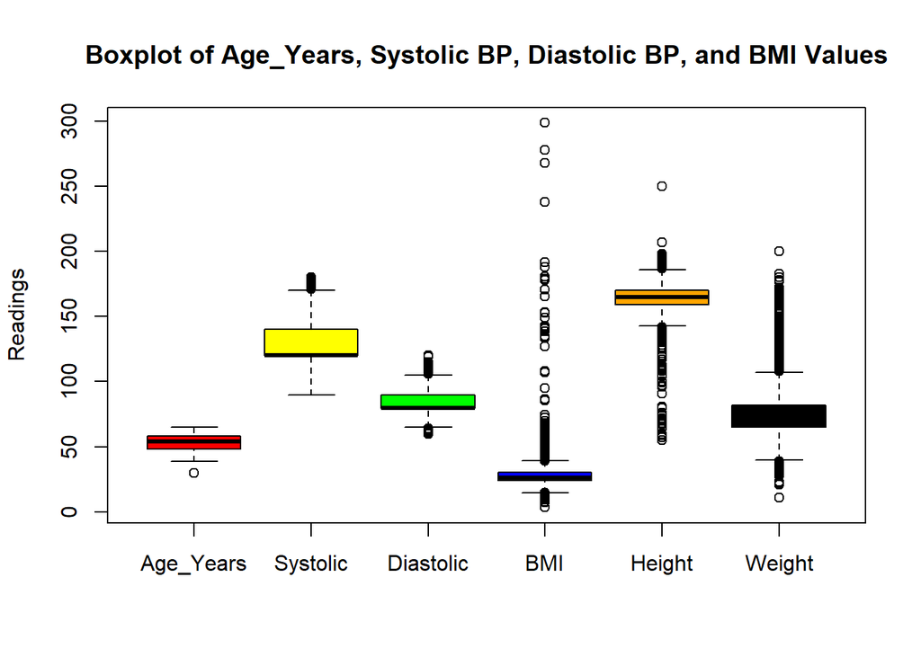

```r
boxplot(Cardio$Age_Years, Cardio$Systolic_BP, Cardio$Diastolic_BP, Cardio$BMI, Cardio$Height, Cardio$Weight,
   main = "Boxplot of Age_Years, Systolic BP, Diastolic BP, and BMI Values",
   ylab = "Readings",
   col = c("Red", "Yellow", "Green", "Blue", "Orange", "Black"),
   names = c("Age_Years", "Systolic", "Diastolic", "BMI", "Height", "Weight"))
```

Density curves allow us to view the distribution of a variable. They also allow us to see patterns of the data and any skewness to the distribution. Below are are the density curves for the six numeric variables. We can see Age_Years is skewed to the left somewhat. We see the greatest frequency for systolic & diastolic BP is at 120 & 80 respectively. BMI is skewed to the right as there is a long thin tail to BMI which we will address before our analysis. Likewise with Height and Weight long tails are seen in these density curves.

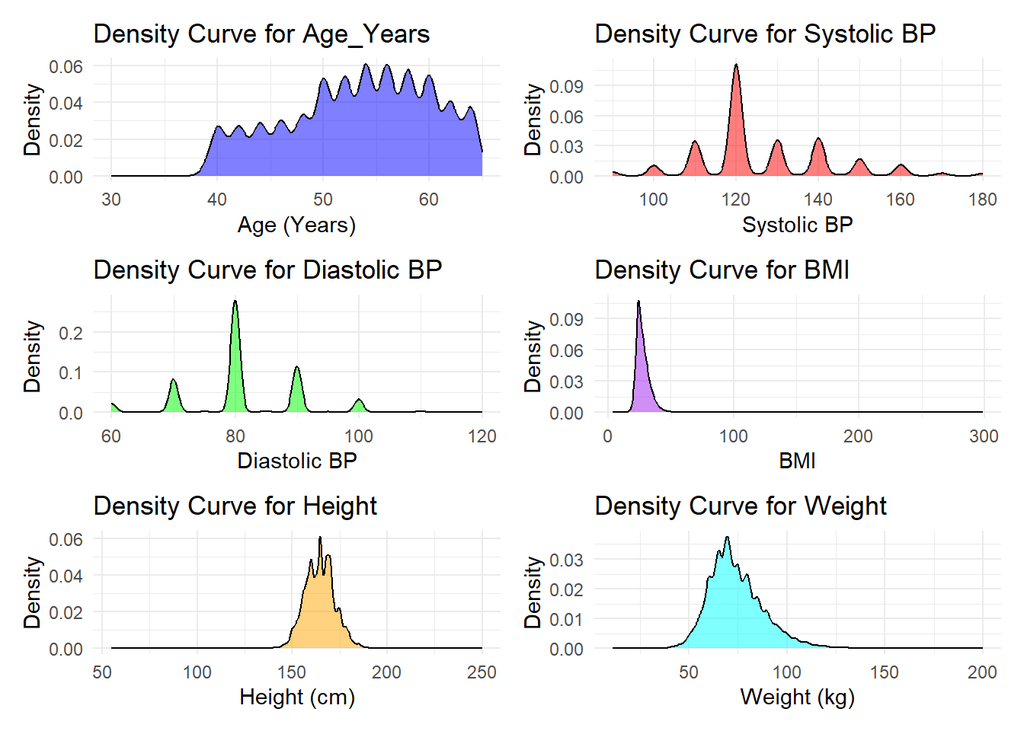

```r
library(ggplot2)
library(patchwork)

plot1 <- ggplot(Cardio, aes(x = Age_Years)) +
  geom_density(fill = "blue", alpha = 0.5) +
  labs(title = "Density Curve for Age_Years", x = "Age (Years)", y = "Density") +
  theme_minimal()

plot2 <-ggplot(Cardio, aes(x = Systolic_BP)) +
  geom_density(fill = "red", alpha = 0.5) +
  labs(title = "Density Curve for Systolic BP", x = "Systolic BP", y = "Density") +
  theme_minimal()

plot3 <-ggplot(Cardio, aes(x = Diastolic_BP)) +
  geom_density(fill = "green", alpha = 0.5) +
  labs(title = "Density Curve for Diastolic BP", x = "Diastolic BP", y = "Density") +
  theme_minimal()

plot4 <-ggplot(Cardio, aes(x = BMI)) +
  geom_density(fill = "purple", alpha = 0.5) +
  labs(title = "Density Curve for BMI", x = "BMI", y = "Density") +
  theme_minimal()

plot5 <-ggplot(Cardio, aes(x = Height)) +
  geom_density(fill = "orange", alpha = 0.5) +
  labs(title = "Density Curve for Height", x = "Height (cm)", y = "Density") +
  theme_minimal()

plot6 <-ggplot(Cardio, aes(x = Weight)) +
  geom_density(fill = "cyan", alpha = 0.5) +
  labs(title = "Density Curve for Weight", x = "Weight (kg)", y = "Density") +
  theme_minimal()

(plot1 + plot2) / (plot3 + plot4) / (plot5 + plot6)
```

### 3.2.1 Data Cleaning

While removing observations is not always the preferred approach, there seems to be some errors in the data collected as mentioned earlier and viewed in the visual representations of the boxplots and density curves. The robustness of our dataset will allow for the removal observations that we’re certain are errors without impacting the accuracy of our analysis. The Min and Max BMI recorded in the dataset is 3.472 & 298.667 respectively. The BMI cut off points for the World Health Organization (WHO) are defined as a person is Severely Underweight: <16 kg/m2 and Morbidly Obese: ≥40.0 kg/m2 (Zierle-Ghosh and Jan 2023) making these min and max values physically impossible raising concerns about the reliability of the dataset. Since BMI is calculated via height and weight, there is a large range of BMI values a person could reasonably have. Therefore, observations where BMI values were less than 15 and greater than 80 (2x high end) were removed from the dataset. The removal of these observations resulted in 56 observations being removed. Additionally since we’re working with an adult dataset, any observations with a height of less 140cm was removed resulting in a new dataset named NewCardio consisting of 68,033 observations. The removal of these 172 observations are inconsequential in terms of the robustness of our data and if given more access to the dataset a proper investigation would be conducted to verify the data entry was conducted correctly.

```r
library(dplyr)

NewCardio <- Cardio %>%
  filter(BMI >= 15 & BMI <= 80)

NewCardio <- NewCardio[NewCardio$Height >= 140, ]
summary(NewCardio)
```

```
       ID             Age            Height          Weight
 Min.   :    0   Min.   :10798   Min.   :140.0   Min.   : 32.00
 1st Qu.:25000   1st Qu.:17656   1st Qu.:159.0   1st Qu.: 65.00
 Median :50020   Median :19700   Median :165.0   Median : 72.00
 Mean   :49975   Mean   :19463   Mean   :164.5   Mean   : 74.11
 3rd Qu.:74879   3rd Qu.:21323   3rd Qu.:170.0   3rd Qu.: 82.00
 Max.   :99999   Max.   :23713   Max.   :207.0   Max.   :200.00
  Systolic_BP     Diastolic_BP         BMI          Age_Years
 Min.   : 90.0   Min.   : 60.00   Min.   :15.01   Min.   :30.00
 1st Qu.:120.0   1st Qu.: 80.00   1st Qu.:23.88   1st Qu.:48.00
 Median :120.0   Median : 80.00   Median :26.31   Median :54.00
 Mean   :126.4   Mean   : 81.27   Mean   :27.43   Mean   :53.29
 3rd Qu.:140.0   3rd Qu.: 90.00   3rd Qu.:30.12   3rd Qu.:58.00
 Max.   :180.0   Max.   :120.00   Max.   :68.31   Max.   :65.00
    Gender            Cholesterol            Glucose             Smoke
 Female:44307   Normal      :51088   Normal      :57881   Non-smoker:62064
 Male  :23726   Above Normal: 9165   Above Normal: 4984   Smoker    : 5969
                High        : 7780   High        : 5168



             Alcohol             Active      CardioDisease
 No alcohol      :64415   Not Active:13360   No :34441
 Consumes alcohol: 3618   Active    :54673   Yes:33592




               Bp_Category
 Elevated            : 3087
 Hypertension Stage 1:39666
 Hypertension Stage 2:15900
 Normal              : 9380
```

The boxplots and density curves were re-run on the NewCardio dataset and we can see via the boxplot a lot of of the physically impossible outliers were removed. The density plots of BMI and Weight were still skewed to the right but this is expected as there is a large range of values for a persons weight and thus corresponding BMI.

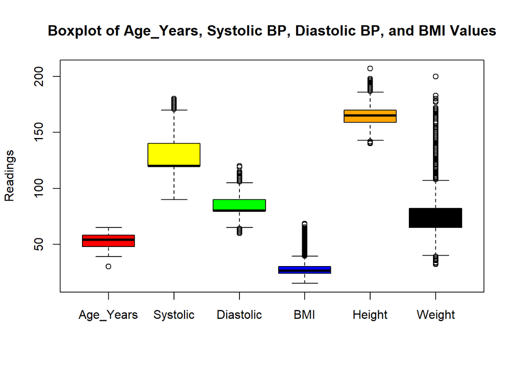

```r
boxplot(NewCardio$Age_Years, NewCardio$Systolic_BP, NewCardio$Diastolic_BP, NewCardio$BMI, NewCardio$Height, NewCardio$Weight,
   main = "Boxplot of Age_Years, Systolic BP, Diastolic BP, and BMI Values",
   ylab = "Readings",
   col = c("Red", "Yellow", "Green", "Blue", "Orange", "Black"),
   names = c("Age_Years", "Systolic", "Diastolic", "BMI", "Height", "Weight"))
```

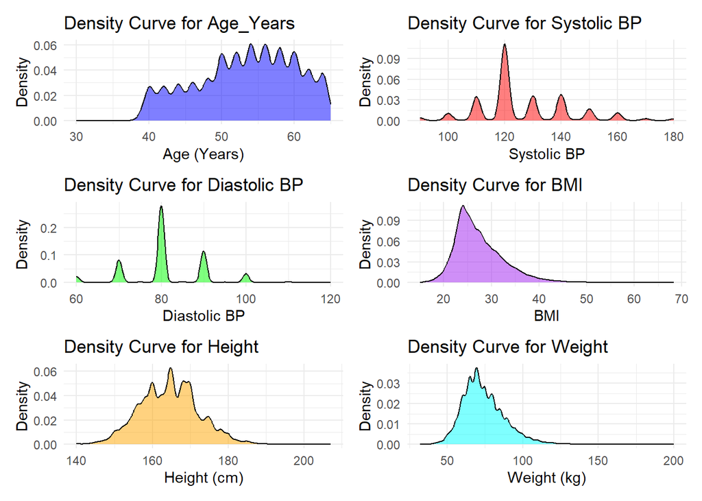

```r
plot7 <- ggplot(NewCardio, aes(x = Age_Years)) +
  geom_density(fill = "blue", alpha = 0.5) +
  labs(title = "Density Curve for Age_Years", x = "Age (Years)", y = "Density") +
  theme_minimal()

plot8 <-ggplot(NewCardio, aes(x = Systolic_BP)) +
  geom_density(fill = "red", alpha = 0.5) +
  labs(title = "Density Curve for Systolic BP", x = "Systolic BP", y = "Density") +
  theme_minimal()

plot9 <-ggplot(NewCardio, aes(x = Diastolic_BP)) +
  geom_density(fill = "green", alpha = 0.5) +
  labs(title = "Density Curve for Diastolic BP", x = "Diastolic BP", y = "Density") +
  theme_minimal()

plot10 <-ggplot(NewCardio, aes(x = BMI)) +
  geom_density(fill = "purple", alpha = 0.5) +
  labs(title = "Density Curve for BMI", x = "BMI", y = "Density") +
  theme_minimal()

plot11 <-ggplot(NewCardio, aes(x = Height)) +
  geom_density(fill = "orange", alpha = 0.5) +
  labs(title = "Density Curve for Height", x = "Height (cm)", y = "Density") +
  theme_minimal()

plot12 <-ggplot(NewCardio, aes(x = Weight)) +
  geom_density(fill = "cyan", alpha = 0.5) +
  labs(title = "Density Curve for Weight", x = "Weight (kg)", y = "Density") +
  theme_minimal()

(plot7 + plot8) / (plot9 + plot10) / (plot11 + plot12)
```

Since we will not be utilizing the variable BMI in our analysis as it is a calculation of Height and Weight and could introduce collinearity, we performed a log transformation on only the weight variable.

```r
library(moments)
skewness_weight <- skewness(NewCardio$Weight, na.rm = TRUE)
skewness_height <- skewness(NewCardio$Height, na.rm = TRUE)
skewness_age_years <- skewness(NewCardio$Age_Years, na.rm = TRUE)
skewness_bmi <- skewness(NewCardio$BMI, na.rm = TRUE)

cat("Skewness of Weight:", skewness_weight, "\n")
```

```
Skewness of Weight: 0.9941015
```

```r
cat("Skewness of Height:", skewness_height, "\n")
```

```
Skewness of Height: 0.152081
```

```r
cat("Skewness of Age Years:", skewness_age_years, "\n")
```

```
Skewness of Age Years: -0.3038593
```

```r
cat("Skewness of BMI:", skewness_bmi, "\n")
```

```
Skewness of BMI: 1.19436
```

```r
NewCardio$Log_Weight <- log(NewCardio$Weight + 1)
```

We can see that by implementing the transformation for Weight, we’ve significantly reduced the skewness to 0.2681562.

```r
plot26 <- ggplot(NewCardio, aes(x = Log_Weight)) +
  geom_histogram(bins = 30, fill = "orange", alpha = 0.7) +
  labs(title = "Log-Transformed Distribution of Weight", x = "Log(Weight)", y = "Frequency") +
  theme_minimal()

plot27 <- ggplot(NewCardio, aes(x = Log_Weight)) +
  geom_density(fill = "orange", alpha = 0.5) +
  labs(title = "Density Plot of Log-Transformed Weight", x = "Log(Weight)", y = "Density") +
  theme_minimal()

skewness_log_Weight <- skewness(NewCardio$Log_Weight, na.rm = TRUE)

cat("Skewness of Log BMI:", skewness_log_Weight, "\n")
```

```
Skewness of Log BMI: 0.2681562
```

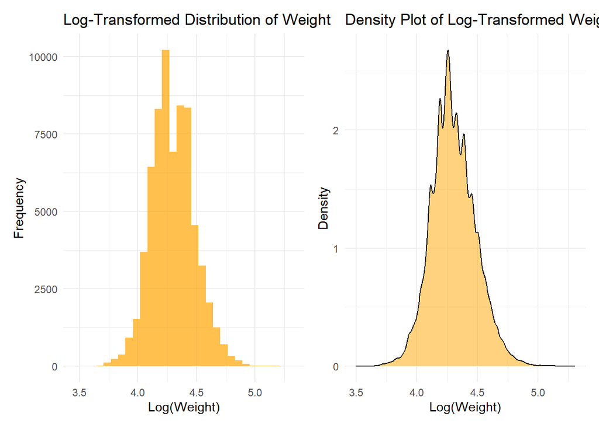

```r
(plot26 + plot27)
```

Below we see the distribution of our categorical variables via histograms minus Gender variable where we previously mention there are ~2x females in the dataset than those of men. The CardioDisease variable was also left out as the distributions was relatively the equal for patients with and without cardiovascular diseases. We can see the distribution shape of Cholesterol and Glucose are relatively similar just with more patients with normal Glucose levels than that of patients with normal cholesterol. We also see that most patients are non-smokers and physically active. Lastly, we also see the majority of the patients fall into some sort of hypertension stage category.

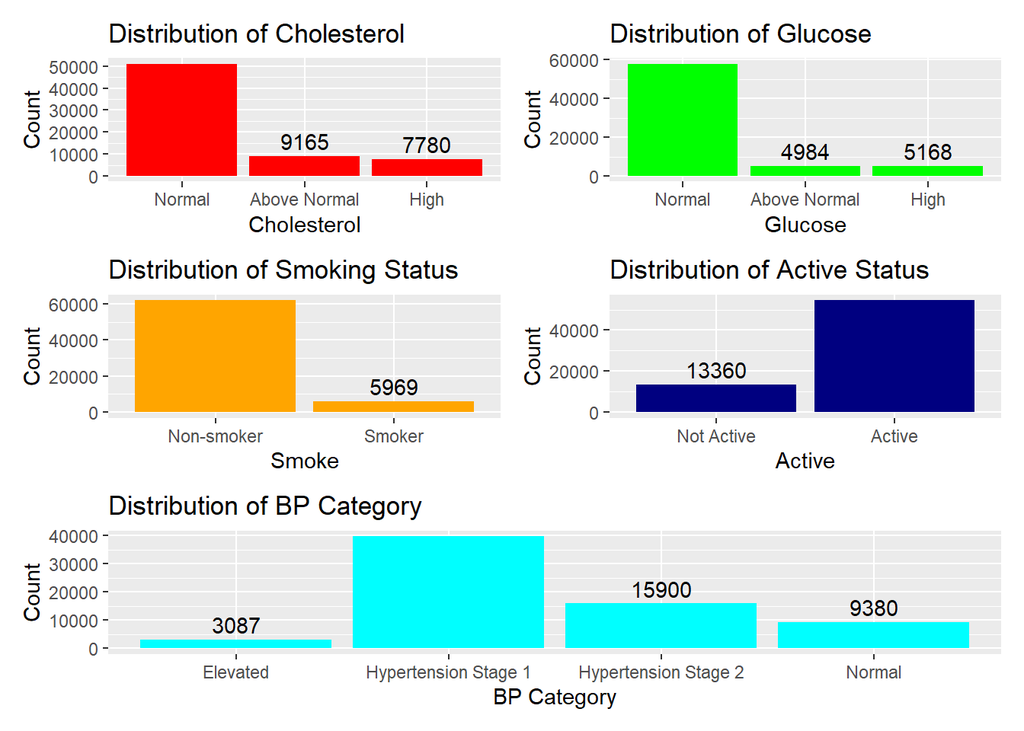

```r
plot13 <- ggplot(NewCardio, aes(x = Cholesterol)) +
  geom_bar(fill = "Red") +
  geom_text(stat = 'count', aes(label = ..count..), vjust = -0.4, color = "black") +
  labs(title = "Distribution of Cholesterol", x = "Cholesterol", y = "Count")

plot14 <- ggplot(NewCardio, aes(x = Glucose)) +
  geom_bar(fill = "Green") +
  geom_text(stat = 'count', aes(label = ..count..), vjust = -0.4, color = "black") +
  labs(title = "Distribution of Glucose", x = "Glucose", y = "Count")

plot15 <- ggplot(NewCardio, aes(x = Smoke)) +
  geom_bar(fill = "Orange") +
  geom_text(stat = 'count', aes(label = ..count..), vjust = -0.4, color = "black") +
  labs(title = "Distribution of Smoking Status", x = "Smoke", y = "Count")

plot16 <- ggplot(NewCardio, aes(x = Active)) +
  geom_bar(fill = "Navy Blue") +
  geom_text(stat = 'count', aes(label = ..count..), vjust = -0.4, color = "black") +
  labs(title = "Distribution of Active Status", x = "Active", y = "Count")

plot17 <- ggplot(NewCardio, aes(x = Bp_Category)) +
  geom_bar(fill = "Cyan") +
  geom_text(stat = 'count', aes(label = ..count..), vjust = -0.4, color = "black") +
  labs(title = "Distribution of BP Category", x = "BP Category", y = "Count")


(plot13 + plot14) / (plot15 + plot16) / plot17
```

Below is a boxplot of Log_Weight by CardioDisease status. We can see that the patients without a cardiovascular disease appear to weight slightly less on average than the patients with cardiovascular disease. The 2nd boxplot shows the weight of the patients grouped by cholesterol status where it was observed that as patients category of cholester increases from normal, above normal, and high the patient’s on average Log_Weight increases.

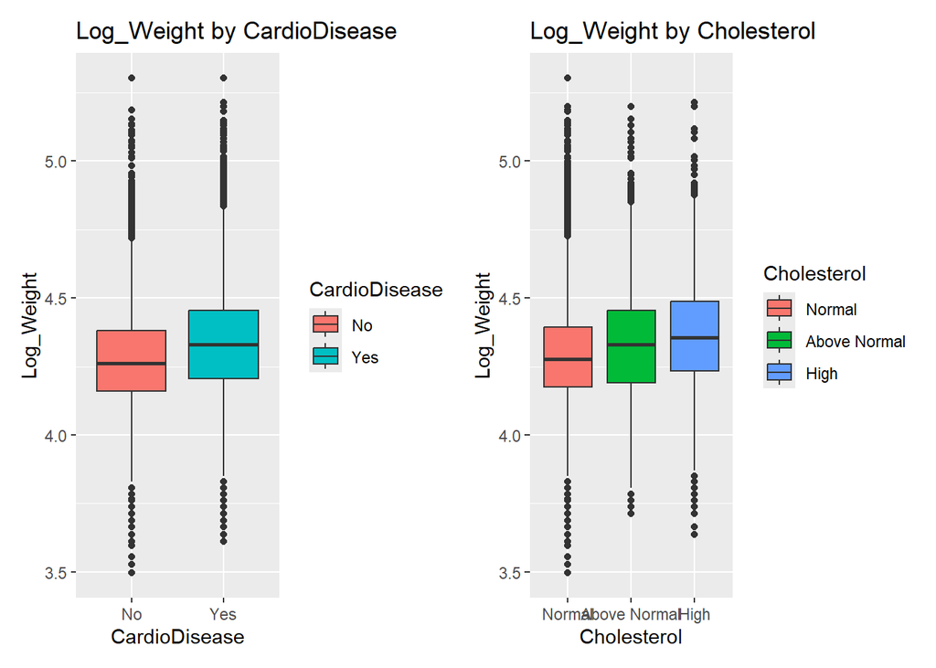

```r
library(patchwork)
plot18 <- ggplot(NewCardio, aes(x = CardioDisease, y = Log_Weight, fill = CardioDisease)) +
  geom_boxplot() +
  labs(title = "Log_Weight by CardioDisease", x = "CardioDisease", y = "Log_Weight")

plot19 <-ggplot(NewCardio, aes(x = Cholesterol, y = Log_Weight, fill = Cholesterol)) +
  geom_boxplot() +
  labs(title = "Log_Weight by Cholesterol", x = "Cholesterol", y = "Log_Weight")

(plot18 + plot19)
```

Below we see the frequency tables for the categorical data stratified by CardioDisease. We see for both cholesterol and glucose that the normal and above normal patients aren’t disproportionately showing cardiovacular diseases. However, the patients that have high values for these variables they do show an uneven weighting of having cardiovascular disease vs not. Another very noticeable output from the tables was that patients with Hypertension Stage 2 BP are showing to have an 80% chance of having a cardiovascular disease.

```r
library(knitr)

Cardio_Cholesterol <- table(NewCardio$CardioDisease, NewCardio$Cholesterol)
Cardio_Glucose <- table(NewCardio$CardioDisease, NewCardio$Glucose)
Cardio_Smoke <- table(NewCardio$CardioDisease, NewCardio$Smoke)
Cardio_Gender <- table(NewCardio$CardioDisease, NewCardio$Gender)
Cardio_BP <- table(NewCardio$CardioDisease, NewCardio$Bp_Category)

kable(Cardio_Cholesterol, caption = "CardioDisease and Cholesterol Frequency Table")
```

CardioDisease and Cholesterol Frequency Table

|  | Normal | Above Normal | High |
| --- | --- | --- | --- |
| No | 28874 | 3709 | 1858 |
| Yes | 22214 | 5456 | 5922 |

```r
kable(Cardio_Glucose, caption = "CardioDisease and Glucose Frequency Table")
```

CardioDisease and Glucose Frequency Table

|  | Normal | Above Normal | High |
| --- | --- | --- | --- |
| No | 30391 | 2064 | 1986 |
| Yes | 27490 | 2920 | 3182 |

```r
kable(Cardio_Smoke, caption = "CardioDisease and Smoking Status Frequency Table")
```

CardioDisease and Smoking Status Frequency Table

|  | Non-smoker | Smoker |
| --- | --- | --- |
| No | 31260 | 3181 |
| Yes | 30804 | 2788 |

```r
kable(Cardio_Gender, caption = "CardioDisease and Gender Frequency Table")
```

CardioDisease and Gender Frequency Table

|  | Female | Male |
| --- | --- | --- |
| No | 22529 | 11912 |
| Yes | 21778 | 11814 |

```r
kable(Cardio_BP, caption = "CardioDisease and BP Category Frequency Table")
```

CardioDisease and BP Category Frequency Table

|  | Elevated | Hypertension Stage 1 | Hypertension Stage 2 | Normal |
| --- | --- | --- | --- | --- |
| No | 2091 | 21881 | 3167 | 7302 |
| Yes | 996 | 17785 | 12733 | 2078 |

We see below when stratifying by CardioDisease that patients without a cardiovascular disease on average weight slightly less than that of their counterpart with cardiovascular disease regardless of their gender, smoker status, and whether they are active or not.

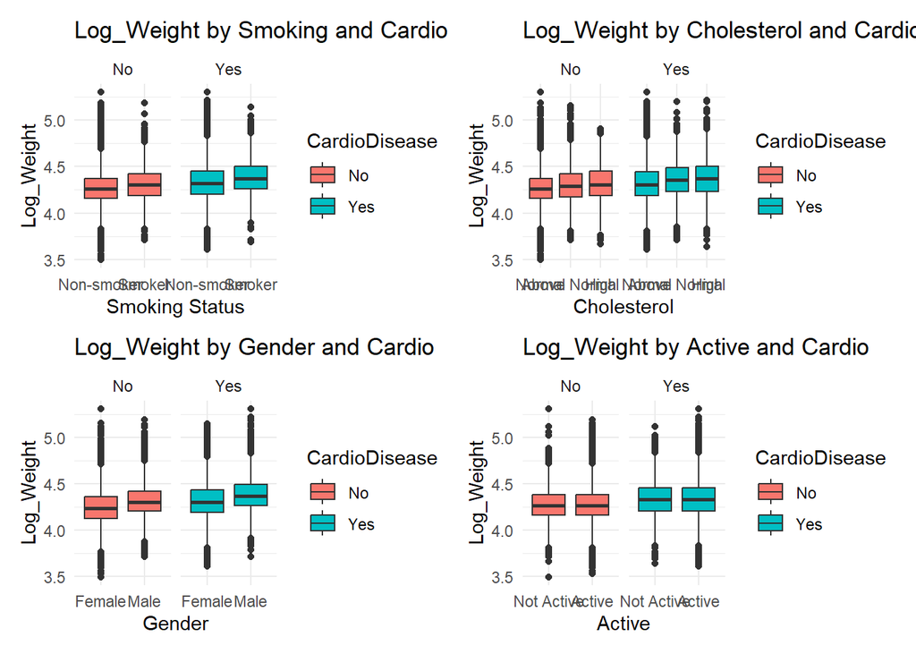

```r
plot20 <-ggplot(NewCardio, aes(x = Smoke, y = Log_Weight, fill = CardioDisease)) +
  geom_boxplot() +
  labs(title = "Log_Weight by Smoking and Cardio",
       x = "Smoking Status",
       y = "Log_Weight") +
  facet_wrap(~ CardioDisease) +
  theme_minimal()

plot21 <-ggplot(NewCardio, aes(x = Cholesterol, y = Log_Weight, fill = CardioDisease)) +
  geom_boxplot() +
  labs(title = "Log_Weight by Cholesterol and Cardio",
       x = "Cholesterol",
       y = "Log_Weight") +
  facet_wrap(~ CardioDisease) +
  theme_minimal()

plot22 <-ggplot(NewCardio, aes(x = Gender, y = Log_Weight, fill = CardioDisease)) +
  geom_boxplot() +
  labs(title = "Log_Weight by Gender and Cardio",
       x = "Gender",
       y = "Log_Weight") +
  facet_wrap(~ CardioDisease) +
  theme_minimal()

plot23 <-ggplot(NewCardio, aes(x = Active, y = Log_Weight, fill = CardioDisease)) +
  geom_boxplot() +
  labs(title = "Log_Weight by Active and Cardio",
       x = "Active",
       y = "Log_Weight") +
  facet_wrap(~ CardioDisease) +
  theme_minimal()

(plot20 + plot21) / (plot22 + plot23)
```

## 3.3 Accessing Pairwise Plots

We see in the pairwise plots that BMI and Weight have a strong correlation which is expected given that BMI is calculated from height and weight. The decision was made to drop the variable BMI from subsequent analysis due to it’s strong positive correlation with weight of 0.868 posing a risk for multi-collinearity. Also due to the fact it is a calculation of height and weight. We’re also more interested in the weight of the patient as it give a better overall picture of a persons physical characteristics instead of keeping just BMI and dropping height and weight. We also see as expected that height and BMI are negatively correlated where as height increases BMI decreases. A less strong positive correlation is that of systolic and diastolic BP with BMI being nearly the same at 0.268 & 0.240 respectively. We also see a weak positive correlation as Age_Years increase as does BMI.

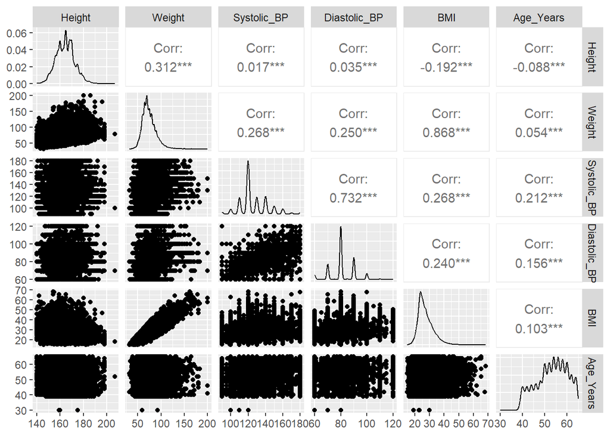

```r
library(GGally)
PairwisePlots <- NewCardio[, c("Height", "Weight", "Systolic_BP", "Diastolic_BP", "BMI", "Age_Years")]

ggpairs(PairwisePlots)
```

```r
cor(PairwisePlots)
```

```
                  Height     Weight Systolic_BP Diastolic_BP        BMI
Height        1.00000000 0.31237794  0.01744733   0.03483035 -0.1923039
Weight        0.31237794 1.00000000  0.26818027   0.24977203  0.8675856
Systolic_BP   0.01744733 0.26818027  1.00000000   0.73166255  0.2677183
Diastolic_BP  0.03483035 0.24977203  0.73166255   1.00000000  0.2398142
BMI          -0.19230394 0.86758558  0.26771833   0.23981424  1.0000000
Age_Years    -0.08752911 0.05415789  0.21169328   0.15602459  0.1030421
               Age_Years
Height       -0.08752911
Weight        0.05415789
Systolic_BP   0.21169328
Diastolic_BP  0.15602459
BMI           0.10304214
Age_Years     1.00000000
```

The decision was made looking at the correlation of Systolic & Diastolic BP’s and their associated scatterplots with Log_Weight to combine these two variables by taking the average of the two into the variable: Combined_BP. This will reduce the multicollinearity as we see the slopes of the line are nearly identical.

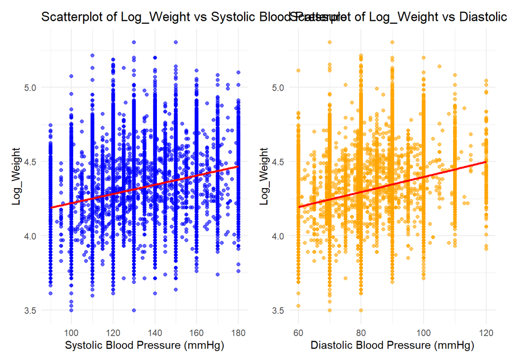

```r
plot24 <- ggplot(NewCardio, aes(x = Systolic_BP, y = Log_Weight)) +
  geom_point(color = "blue", alpha = 0.6) +
  geom_smooth(method = "lm", color = "red") +
  labs(title = "Scatterplot of Log_Weight vs Systolic Blood Pressure",
       x = "Systolic Blood Pressure (mmHg)",
       y = "Log_Weight") +
  theme_minimal()

plot25 <- ggplot(NewCardio, aes(x = Diastolic_BP, y = Log_Weight)) +
  geom_point(color = "orange", alpha = 0.6) +
  geom_smooth(method = "lm", color = "red") +
  labs(title = "Scatterplot of Log_Weight vs Diastolic Blood Pressure",
       x = "Diastolic Blood Pressure (mmHg)",
       y = "Log_Weight") +
  theme_minimal()

NewCardio$Combined_BP <- (NewCardio$Systolic_BP + NewCardio$Diastolic_BP) / 2

(plot24 + plot25)
```

# 4 Statistical Regression Modeling

## 4.1 Linear Regression Modeling

### 4.1.1 Statement of the Question(s)

Our objective for building a linear regression model was to address the question: What explanatory variables are significant in predicting a patients’ Log_Weight and what is the relationship between our explanatory variables and the response variable Log_Weight? In order words, which variables are significant in helping us determine a patients’ weight. The purpose of the subsequent analysis conducted focused on association and subsequent prediction.

### 4.1.2 Data Justification

Our justification of utilizing this dataset is very solid as our sample size is Very robust with 68,033 observations and no missing values. The dataset includes both continuous variables and categorical variables set up as factors with levels. The response variable Log_Weight is a continuous variable for which we have done a transformation on it to reduce the skewness of the distribution. Additionally, We observed correlations between the continuous variables and Weight therefore supporting the use of linear regression.Since our data contains continuous and categorical variables, this will enhance the model’s explanatory power giving us a stronger model to provide predictions of Log_Weight if given explanatory inputs.

Given the aforementioned points regarding the data, we believe there is ample justification for using a linear regression model to model the relationship between Log_Weight and selected explanatory variables.

Below we see the 3 model summaries, and we will focus on the stepwise selection for reasons detailed further in the analysis. We see there are many statistically significant explanatory variables involved in determining the weight of a patient, even taking into the other explanatory variables in the model. We see that all the regression coefficients are positive except those of Active where the patient was physically active and gender where the patient was male. This shows us a negative correlation between Weight and activity level, as well as weight and male patients. We see that for every 1 unit increase in GlucoseAboveNormal the corresponding Log_Weight increases on average by 0.0482311. Whereas, for every 1 unit increase in GlucoseHigh the patients Log_Weight only increases by 0.0155445. Perhaps, those patients who have very high glucose may be diabetic and are more mindful of their weight resulting in a less increase in Weight.

The resulting Linear Model Regression equation:

$LogWeight = 2.5261843 + 0.0038556*Combined BP + 0.0005779*AgeYears + 0.0234864*CholesterAboveNormal + 0.0462264*CholesterolHigh \\ + 0.0482311*GlucoseAboveNormal +0.0155445*GlucoseHigh - 0.0060168*ActiveActive - 0.0103789*GenderMale + 0.0081468*Height + \epsilon$.

## 4.2 Model Selection

```r
library(MASS)
library(knitr)

full_model <- lm(Log_Weight ~ Combined_BP + Age_Years + Smoke + Cholesterol + Glucose + Active + Gender + Height, data = NewCardio)

forward_model <- stepAIC(full_model, direction = "forward", trace = 0)

backward_model <- stepAIC(full_model, direction = "backward", trace = 0)

stepwise_model <- stepAIC(full_model, direction = "both", trace = 0)

kable(summary(forward_model)$coef, caption = "Summary statistics of the regression coefficients for the forward model")
```

Summary statistics of the regression coefficients for the forward model

|  | Estimate | Std. Error | t value | Pr(>\|t\|) |
| --- | --- | --- | --- | --- |
| (Intercept) | 2.5263029 | 0.0171575 | 147.2421487 | 0.0000000 |
| Combined_BP | 0.0038553 | 0.0000554 | 69.5540406 | 0.0000000 |
| Age_Years | 0.0005811 | 0.0000957 | 6.0721459 | 0.0000000 |
| SmokeSmoker | 0.0017806 | 0.0023519 | 0.7570671 | 0.4490123 |
| CholesterolAbove Normal | 0.0234390 | 0.0019375 | 12.0972870 | 0.0000000 |
| CholesterolHigh | 0.0461887 | 0.0023082 | 20.0111143 | 0.0000000 |
| GlucoseAbove Normal | 0.0482135 | 0.0025073 | 19.2294036 | 0.0000000 |
| GlucoseHigh | 0.0155677 | 0.0027044 | 5.7564388 | 0.0000000 |
| ActiveActive | -0.0060457 | 0.0015739 | -3.8411642 | 0.0001226 |
| GenderMale | -0.0107217 | 0.0016075 | -6.6697655 | 0.0000000 |
| Height | 0.0081452 | 0.0000946 | 86.1294655 | 0.0000000 |

```r
kable(summary(backward_model)$coef, caption = "Summary statistics of the regression coefficients for the backward model")
```

Summary statistics of the regression coefficients for the backward model

|  | Estimate | Std. Error | t value | Pr(>\|t\|) |
| --- | --- | --- | --- | --- |
| (Intercept) | 2.5261843 | 0.0171567 | 147.241838 | 0.0000000 |
| Combined_BP | 0.0038556 | 0.0000554 | 69.560719 | 0.0000000 |
| Age_Years | 0.0005779 | 0.0000956 | 6.044587 | 0.0000000 |
| CholesterolAbove Normal | 0.0234864 | 0.0019365 | 12.128124 | 0.0000000 |
| CholesterolHigh | 0.0462264 | 0.0023076 | 20.032183 | 0.0000000 |
| GlucoseAbove Normal | 0.0482311 | 0.0025072 | 19.237335 | 0.0000000 |
| GlucoseHigh | 0.0155445 | 0.0027042 | 5.748225 | 0.0000000 |
| ActiveActive | -0.0060168 | 0.0015735 | -3.823943 | 0.0001315 |
| GenderMale | -0.0103789 | 0.0015424 | -6.728969 | 0.0000000 |
| Height | 0.0081468 | 0.0000945 | 86.168398 | 0.0000000 |

```r
kable(summary(stepwise_model)$coef, caption = "Summary statistics of the regression coefficients for the stepwise model")
```

Summary statistics of the regression coefficients for the stepwise model

|  | Estimate | Std. Error | t value | Pr(>\|t\|) |
| --- | --- | --- | --- | --- |
| (Intercept) | 2.5261843 | 0.0171567 | 147.241838 | 0.0000000 |
| Combined_BP | 0.0038556 | 0.0000554 | 69.560719 | 0.0000000 |
| Age_Years | 0.0005779 | 0.0000956 | 6.044587 | 0.0000000 |
| CholesterolAbove Normal | 0.0234864 | 0.0019365 | 12.128124 | 0.0000000 |
| CholesterolHigh | 0.0462264 | 0.0023076 | 20.032183 | 0.0000000 |
| GlucoseAbove Normal | 0.0482311 | 0.0025072 | 19.237335 | 0.0000000 |
| GlucoseHigh | 0.0155445 | 0.0027042 | 5.748225 | 0.0000000 |
| ActiveActive | -0.0060168 | 0.0015735 | -3.823943 | 0.0001315 |
| GenderMale | -0.0103789 | 0.0015424 | -6.728969 | 0.0000000 |
| Height | 0.0081468 | 0.0000945 | 86.168398 | 0.0000000 |

```r
library(car)
r.full.model = summary(full_model)$r.squared
r.forward.model = summary(forward_model)$r.squared
r.backward.model = summary(backward_model)$r.squared
r.stepwise.model = summary(stepwise_model)$r.squared

Rsquare = cbind(Full_Model = r.full.model,Forward_Model = r.forward.model,Backward_Model = r.backward.model,Stepwise_Model = r.stepwise.model)

kable(Rsquare, caption = "R-squared's for the four candidate models")
```

R-squared’s for the four candidate models

| Full_Model | Forward_Model | Backward_Model | Stepwise_Model |
| --- | --- | --- | --- |
| 0.2023632 | 0.2023632 | 0.2023565 | 0.2023565 |

```r
aic_full = AIC(full_model)
aic_forward = AIC(forward_model)
aic_backward = AIC(backward_model)
aic_stepwise = AIC(stepwise_model)

AIC_values = data.frame(Model = c("Full Model", "Forward Model", "Backward Model", "Stepwise Model"),
  AIC = c(aic_full, aic_forward, aic_backward, aic_stepwise))

print(AIC_values)
```

```
           Model       AIC
1     Full Model -53768.48
2  Forward Model -53768.48
3 Backward Model -53769.91
4 Stepwise Model -53769.91
```

```r
model_weight <- lm(Log_Weight ~ Combined_BP + Gender + Smoke + Cholesterol + Age_Years + Glucose + Alcohol + Active + Height, data = NewCardio)

vif_results_weight <- vif(model_weight)
print(vif_results_weight)
```

```
                GVIF Df GVIF^(1/(2*Df))
Combined_BP 1.085862  1        1.042047
Gender      1.507796  1        1.227923
Smoke       1.245882  1        1.116191
Cholesterol 1.480075  2        1.102988
Age_Years   1.073255  1        1.035980
Glucose     1.416988  2        1.091042
Alcohol     1.137358  1        1.066470
Active      1.001721  1        1.000860
Height      1.391088  1        1.179444
```

```r
residuals_stepwise <- residuals(stepwise_model)

residuals_summary <- data.frame(
  Min = min(residuals_stepwise),
  Median = median(residuals_stepwise),
  Max = max(residuals_stepwise))

residuals_summary$Model <- "Stepwise Model"

kable(residuals_summary, caption = "Residuals Summary for the Stepwise Model")
```

Residuals Summary for the Stepwise Model

| Min | Median | Max | Model |
| --- | --- | --- | --- |
| -0.7033852 | -0.0151456 | 0.9177639 | Stepwise Model |

We see below our Mean Absolute Error (MAE) and Root Mean Square Error(RMSE) indicate the errors on a set of predictions with our stepwise model are relatively close to the actual predictions shown by the low values below. This is indicative of a relatively well performing overall model.

```r
predictions_stepwise <- predict(stepwise_model, NewCardio)
actual_values <- NewCardio$Log_Weight
mae <- mean(abs(predictions_stepwise - actual_values))
rmse <- sqrt(mean((predictions_stepwise - actual_values)^2))

accuracy_results <- data.frame(Metric = c("MAE", "RMSE"), Value = c(mae, rmse))
print(accuracy_results)
```

```
  Metric     Value
1    MAE 0.1278119
2   RMSE 0.1629559
```

Using 4 new created observations, we input the data into our stepwise model and returned the Log_Weights of the 4 observations. We then exponentiation them back to kg for ease of interpretability.

```r
new_obs <- data.frame(
  Combined_BP = c(90, 110, 140, 150),
  Age_Years = c(40, 51, 55, 62),
  Smoke = c("No", "Yes", "No", "Yes"),
  Cholesterol = c("Normal", "Above Normal", "High", "Normal"),
  Glucose = c("Normal", "Above Normal", "High", "Normal"),
  Active = c("Active", "Not Active", "Active", "Not Active"),
  Gender = c("Male", "Female", "Male", "Female"),
  Height = c(170, 160, 200, 180))

predicted_Log_Weight<- predict(stepwise_model, newdata = new_obs)

predicted_log_weight <- c(4.264865, 4.354979, 4.772487, 4.606777)

predicted_weights <- exp(predicted_log_weight)

results <- data.frame(Predicted_Log_Weight = predicted_Log_Weight,Predicted_Weight = predicted_weights)

kable(results, caption = "Predicted Log_Weight and Actual Weights for New Observations")
```

Predicted Log_Weight and Actual Weights for New Observations

| Predicted_Log_Weight | Predicted_Weight |
| --- | --- |
| 4.264865 | 71.15531 |
| 4.354979 | 77.86519 |
| 4.772488 | 118.21287 |
| 4.606777 | 100.16081 |

Lastly, for our linear model we performed cross validation splitting up the dataset into 10-folds and using the “cv” cross validation method to perform it. The R^2 tells us that our model accounts for ~20% of the variance in the variable Log_Weight.

```r
library(caret)

set.seed(123)
control_linear <- trainControl(method = "cv", number = 10)

linear_model_cv <- train(Log_Weight ~ Combined_BP + Age_Years + Smoke + Cholesterol + Glucose + Active + Gender + Height, data = NewCardio,
method = "lm", trControl = control_linear)

print(linear_model_cv)
```

```
Linear Regression

68033 samples
    8 predictor

No pre-processing
Resampling: Cross-Validated (10 fold)
Summary of sample sizes: 61228, 61229, 61231, 61230, 61229, 61231, ...
Resampling results:

  RMSE       Rsquared   MAE
  0.1629789  0.2021407  0.1278321

Tuning parameter 'intercept' was held constant at a value of TRUE
```

## 4.3 Logistic Regression Modeling

As stated previously in the linear regression modeling our data is very well suited for logistic regression modelling as well. We first fit the initial regression model with CardioDisease as the response variable and all the predictor variables in the dataset minus BMI, systolic and diastolic BP since Weight, Height, and Bp_category encompass those variables to avoid multicollinearity.

We see in the summary of the significant tests that gender and having a glucose of above normal is not significant at the 0.05 level. While it looks like Bp_CategoryHypertension Stage 2, Log_Weight, and CholesterolHigh all have the highest regression coefficients increasing the log odds of a positive (CardioDisease Yes) event the most. We also see numerous negative relationships indicating they reduce the log odds.

```r
Logistic_Model <- glm(CardioDisease ~ Bp_Category + Age_Years + Height + Log_Weight + Gender + Cholesterol + Glucose +
  Smoke + Alcohol + Active,
  family = binomial,data = NewCardio)

coefficient.table = summary(Logistic_Model)$coef

kable(coefficient.table, caption = "Summary of the significant tests of the logistic regression model")
```

Summary of the significant tests of the logistic regression model

|  | Estimate | Std. Error | z value | Pr(>\|z\|) |
| --- | --- | --- | --- | --- |
| (Intercept) | -7.8420774 | 0.2810396 | -27.9038122 | 0.0000000 |
| Bp_CategoryHypertension Stage 1 | 0.4206942 | 0.0412978 | 10.1868505 | 0.0000000 |
| Bp_CategoryHypertension Stage 2 | 1.8879132 | 0.0450216 | 41.9335000 | 0.0000000 |
| Bp_CategoryNormal | -0.3769341 | 0.0475937 | -7.9198326 | 0.0000000 |
| Age_Years | 0.0579516 | 0.0013349 | 43.4122940 | 0.0000000 |
| Height | -0.0083578 | 0.0013699 | -6.1010864 | 0.0000000 |
| Log_Weight | 1.2839130 | 0.0529145 | 24.2639254 | 0.0000000 |
| GenderMale | 0.0167618 | 0.0219585 | 0.7633391 | 0.4452612 |
| CholesterolAbove Normal | 0.4353897 | 0.0266673 | 16.3267400 | 0.0000000 |
| CholesterolHigh | 1.1965104 | 0.0351385 | 34.0512683 | 0.0000000 |
| GlucoseAbove Normal | 0.0350187 | 0.0352475 | 0.9935084 | 0.3204623 |
| GlucoseHigh | -0.3601881 | 0.0390365 | -9.2269672 | 0.0000000 |
| SmokeSmoker | -0.1095800 | 0.0341184 | -3.2117549 | 0.0013193 |
| AlcoholConsumes alcohol | -0.1966451 | 0.0415259 | -4.7354770 | 0.0000022 |
| ActiveActive | -0.2236212 | 0.0215585 | -10.3727547 | 0.0000000 |

The reduced model will include the practically important variables considered for this analysis albeit most of the variables in the dataset could make an argument to be included will be limited to Bp_Category, Age_years, Cholesterol, and Log_Weight. Active, Smoke, and alcohol were not selected as we are not privy to knowing the values for the patients for these variables and are reliant on the binned variables. We performed the analysis using the “both” functionality for direction which is essentially the same as stepwise for linear regression. The result is very similar to the initial model minus removing gender as not significant.

The resulting Logistic Model Regression equation:

$Logit(p) = -7.9157441 + 0.4208538*BpCategory Hypertension 1 + 1.8885847*BpCategory Hypertension 2 - 0.3774414*BpCategoryNormal + \\ 0.0579817*AgeYears - 0.0078703*Height + 1.2832004*LogWeight + 0.4349982*CholesterolAboveNormal + 1.1961829*CholesterolHigh \\ + 0.0350072*GlucoseAboveNormal - 0.3604139*GlucoseHigh - 0.1030532*SmokerSmoker - 0.1949753*AlcoholConsumesalcohol - 0.2235626*ActiveActive$

```r
reduced.model <- glm(CardioDisease ~ Bp_Category + Age_Years + Cholesterol + Log_Weight, family = binomial, data = NewCardio)

final.model <- step(Logistic_Model, scope = list(lower = formula(reduced.model),  upper = formula(Logistic_Model)), data = NewCardio,
direction = "both", trace = 0)

final.model.coef <- summary(final.model)$coef

kable(final.model.coef, caption = "Summary table of significant tests")
```

Summary table of significant tests

|  | Estimate | Std. Error | z value | Pr(>\|z\|) |
| --- | --- | --- | --- | --- |
| (Intercept) | -7.9157441 | 0.2639881 | -29.9852268 | 0.0000000 |
| Bp_CategoryHypertension Stage 1 | 0.4208538 | 0.0412980 | 10.1906557 | 0.0000000 |
| Bp_CategoryHypertension Stage 2 | 1.8885847 | 0.0450141 | 41.9554358 | 0.0000000 |
| Bp_CategoryNormal | -0.3774414 | 0.0475893 | -7.9312182 | 0.0000000 |
| Age_Years | 0.0579817 | 0.0013344 | 43.4521599 | 0.0000000 |
| Height | -0.0078703 | 0.0012118 | -6.4945860 | 0.0000000 |
| Log_Weight | 1.2832004 | 0.0529071 | 24.2538631 | 0.0000000 |
| CholesterolAbove Normal | 0.4349982 | 0.0266617 | 16.3154647 | 0.0000000 |
| CholesterolHigh | 1.1961829 | 0.0351358 | 34.0445923 | 0.0000000 |
| GlucoseAbove Normal | 0.0350072 | 0.0352478 | 0.9931726 | 0.3206258 |
| GlucoseHigh | -0.3604139 | 0.0390360 | -9.2328669 | 0.0000000 |
| SmokeSmoker | -0.1030532 | 0.0330311 | -3.1198857 | 0.0018092 |
| AlcoholConsumes alcohol | -0.1949753 | 0.0414676 | -4.7018712 | 0.0000026 |
| ActiveActive | -0.2235626 | 0.0215583 | -10.3701578 | 0.0000000 |

Our VIF values are all below 10 indicating multicollinearity is not a significant issue in our model.

```r
library(car)

vif_values <- vif(final.model)
vif_values
```

```
                GVIF Df GVIF^(1/(2*Df))
Bp_Category 1.045297  3        1.007411
Age_Years   1.026424  1        1.013126
Height      1.193873  1        1.092645
Log_Weight  1.177567  1        1.085158
Cholesterol 1.489552  2        1.104750
Glucose     1.476231  2        1.102272
Smoke       1.166370  1        1.079986
Alcohol     1.136393  1        1.066017
Active      1.002669  1        1.001334
```

We can see below inputting 4 new observations into the dataset allows us to see what the predicted outcome will be at the cut off probability of 0.5. The result was 3 out of the 4 new patients (observations) were classified using our model as not having a cardiovascular disease while 1 was. It should be noted the 1 that was had a Bp_Category of Hypertensions Stage 2.

```r
mynewdata <- data.frame(
  Bp_Category = factor(c("Hypertension Stage 1", "Normal", "Hypertension Stage 2", "Elevated"),
                       levels = c("Elevated", "Hypertension Stage 1", "Hypertension Stage 2", "Normal")),
  Age_Years = c(45, 30, 55, 60),
  Height = c(170, 165, 175, 180),
  Log_Weight = c(log(70), log(60), log(80), log(90)),
  Cholesterol = factor(c("Above Normal", "Normal", "High", "Above Normal"),
                       levels = c("Normal", "Above Normal", "High")),
  Glucose = factor(c("Normal", "Above Normal", "Normal", "Above Normal"),
                   levels = c("Normal", "Above Normal")),
  Smoke = factor(c("Smoker", "Non-smoker", "Smoker", "Smoker"),
                 levels = c("Non-smoker", "Smoker")),
  Alcohol = factor(c("Consumes alcohol", "No alcohol", "Consumes alcohol", "Consumes alcohol"),
                   levels = c("No alcohol", "Consumes alcohol")),
  Active = factor(c("Active", "Not Active", "Not Active", "Active"),
                  levels = c("Active", "Not Active")))

pred.success.prob <- predict(final.model, newdata = mynewdata, type = "response")


cut.off.prob <- 0.5

pred.response <- ifelse(pred.success.prob > cut.off.prob, 1, 0)

mynewdata$Pred.Response <- pred.response

kable(mynewdata, caption = "Predicted Value of response variable with the given cut-off probability")
```

Predicted Value of response variable with the given cut-off probability

| Bp_Category | Age_Years | Height | Log_Weight | Cholesterol | Glucose | Smoke | Alcohol | Active | Pred.Response |
| --- | --- | --- | --- | --- | --- | --- | --- | --- | --- |
| Hypertension Stage 1 | 45 | 170 | 4.248495 | Above Normal | Normal | Smoker | Consumes alcohol | Active | 0 |
| Normal | 30 | 165 | 4.094345 | Normal | Above Normal | Non-smoker | No alcohol | Not Active | 0 |
| Hypertension Stage 2 | 55 | 175 | 4.382027 | High | Normal | Smoker | Consumes alcohol | Not Active | 1 |
| Elevated | 60 | 180 | 4.499810 | Above Normal | Above Normal | Smoker | Consumes alcohol | Active | 0 |

Below we have the Receiver Operating Characteristic (ROC) curve which shows how well a model performs across different thresholds. The best cutoff point is one that maintains the highest sensitivity and specificity at the same time which is seen her in the middle of the curve which is: 0.4754137. The Area Under the Curve (AUC), tells us how accurate the model is and we can see that with an AUC of 0.7648628, the model is fairly accurate.

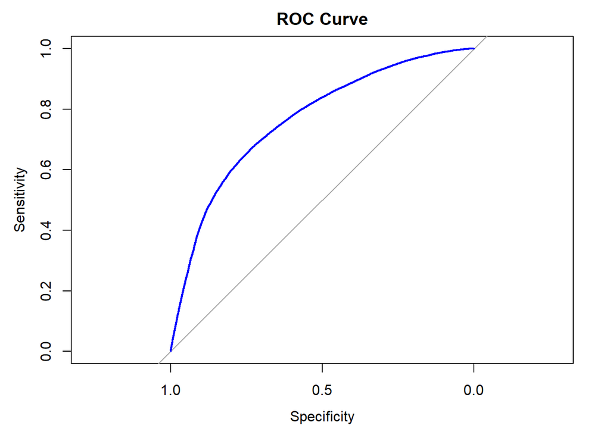

```r
library(pROC)

predicted.probabilities <- predict(final.model, type = "response")

roc_curve <- roc(NewCardio$CardioDisease, predicted.probabilities)

plot(roc_curve, main = "ROC Curve", col = "blue")
```

```r
predicted_probabilities <- predict(Logistic_Model, type = "response")

roc_curve <- roc(NewCardio$CardioDisease, predicted_probabilities)

optimal_index <- coords(roc_curve, "best", ret = "all")
optimal_cutoff <- optimal_index[["threshold"]]

cat("Optimal Cut-off Probability:", optimal_cutoff, "\n")
```

```
Optimal Cut-off Probability: 0.4754137
```

```r
cat("Sensitivity:", optimal_index[["sensitivity"]], "\n")
```

```
Sensitivity: 0.6699214
```

```r
cat("Specificity:", optimal_index[["specificity"]], "\n")
```

```
Specificity: 0.7346767
```

```r
cat("AUC:", auc(roc_curve), "\n")
```

```
AUC: 0.7648628
```

Below we’re performing our cross validation for the logistic regression model the same way we did for the linear model. All that needs to change besides the variables is the method for glm vs lm for linear. We see the accuracy of the model came out to be: 0.7022329.

```r
library(caret)
set.seed(123)

train_control <- trainControl(method = "cv", number = 10)

Logistic_CV <- train(CardioDisease ~ Bp_Category + Age_Years + Height + Log_Weight +
  Cholesterol + Glucose + Smoke + Alcohol + Active,
  data = NewCardio,
  method = "glm",
  family = "binomial",
  trControl = train_control)

print(Logistic_CV)
```

```
Generalized Linear Model

68033 samples
    9 predictor
    2 classes: 'No', 'Yes'

No pre-processing
Resampling: Cross-Validated (10 fold)
Summary of sample sizes: 61229, 61230, 61229, 61229, 61230, 61230, ...
Resampling results:

  Accuracy   Kappa
  0.7022329  0.4033867
```

## 4.4 Results and Conclusion

The results from this in-depth analsysis shows us there are many variables that influence a persons status of whether they have a cardiovascular disease. Perhaps, this is one of the reason that just general overall health is the best medicine as there are numerous variables that can result in increasing a patients’ probability. On the other hand, the linear model for the Log_Weight didn’t yield as promising results as the logistic model did. We were only able to model ~20% of the variance of the Log_Weight variable. I believe this is due to there are many other variables and factors in a patient’s life that has more influence on their weight. We did see however note that patients without cardiovasculars diseases on average weighed less than those with cardiovascular diseases. The variables in this dataset were better put to use looking at the intended response variable of CardioDisease. We still did see some meaningful results where we confirmed a widely known fact that being active has a negative correlation with ones weight and that factors such as having high cholsterol and high glucose are positively correlated indicating indicating that as they increase we would expect the patient’s weight on average to increase as well by way of the regression coefficients identified in the model.

# 5 Summary and Discussion

There are multiple limitations to this dataset, some of which was already discussed in this analysis. The main issue with this dataset is the overall in-depth knowledge of the variables and how the data was obtained is lacking. The type of cardiovascular disease is not identified as there are numerous different cardiovascular diseases. The question is, did all the patients have the same cardiovascular disease or were they all grouped into one? The lumping all patients into one cardiovascular disease group would be very irresponsible if we were to hope to provide valuable defensible statistical analysis for the predictors of cardiovascular disease as not every disease is the same.

The amount of physical activity is ambiguous as we don’t know the metrics that were used to classify each patient and whether it was observed or simply a questionnaire which can be very unreliable means of obtaining data for such a variable. Many people tend to exaggerate characteristics that are seen to be good and underestimate those that are perceived to be bad when given a survey response type of question leading to unreliable data points.

While there were many issues with this dataset, I do believe it is a good starting place to start to look at the overall general idea of how these types of variables affect cardiac health. We would need more descriptive and more refined variables if we were to hope to elicit very meaningful clinical results here. These would be my suggestions to the researcher who compiled this dataset as to not generalize the data as much as they did and to provide values of the raw data and how it was binned in order to get a better understanding of the origin of the data. We noted in the beginning there were some physically impossible values therefore, a view of the raw data values would be best to take any next steps with this data.

# 6 Reference and Appendix

Janosi, A., Steinbrunn, W., Pfisterer, M., & Detrano, R. (1989). Heart Disease [Dataset]. UCI Machine Learning Repository. https://doi.org/10.24432/C52P4X.

Weir CB, Jan A. BMI Classification Percentile And Cut Off Points. [Updated 2023 Jun 26]. In: StatPearls [Internet]. Treasure Island (FL): StatPearls Publishing; 2024 Jan-. Available from: https://www.ncbi.nlm.nih.gov/books/NBK541070/

What is body mass index (BMI)? (2024, June 17). Growth Chart Training. https://www.cdc.gov/growth-chart-training/hcp/using-bmi/body-mass-index.html#:~:text=A%20measure%20of%20weight%20relative%20to%20height&text=The%20equations%20for%20calculating%20BMI,)%20%2F%20%5Bheight%20(m)%5D&text=Metric%20units%3A%20BMI%20%3D%20%5Bweight,height%20(cm)%5D%20x%2010%2C000

Yasserh. (2021, December 29). Heart disease dataset. Kaggle. https://www.kaggle.com/datasets/yasserh/heart-disease-dataset

Zierle-Ghosh A, Jan A. Physiology, Body Mass Index. [Updated 2023 Nov 5]. In: StatPearls [Internet]. Treasure Island (FL): StatPearls Publishing; 2024 Jan-. Available from: https://www.ncbi.nlm.nih.gov/books/NBK535456/